# Investigate low DOC

David Nguyen

2022-04-20

```r
library(tidyverse)
library(viridis)
# source("Code/masterDataVARIABLES.R")
setwd("C://Users//david//Documents//STOICH//STOICH.Aim1//Code/DNguyen")
#write.csv(ALL_CNP, "ALL_CNP.csv", row.names = FALSE)
ALL_CNP <- read.csv("ALL_CNP.csv")
```

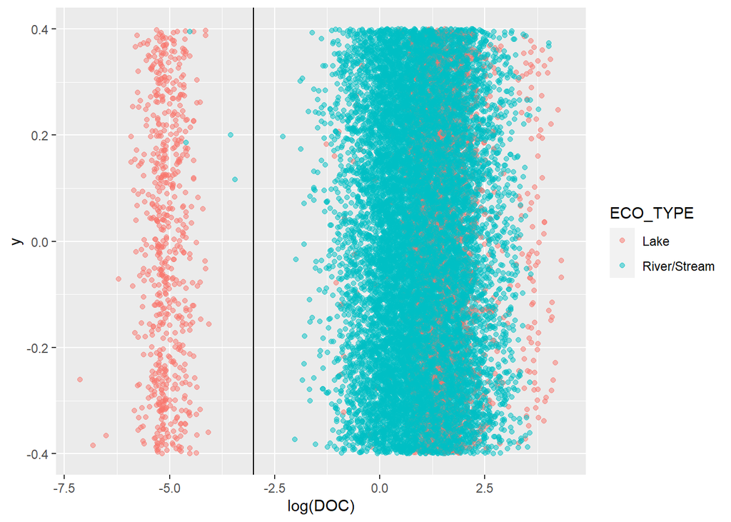

```r
ALL_CNP %>%
  ggplot() +
  geom_jitter(aes(x = log(DOC), y = 0, col = ECO_TYPE), width = 0, alpha = 0.5) +
  geom_vline(xintercept = -3)
```

DOC clusters our data into 2 groups. Most of the low DOC data are lakes with a few rivers scattered within the low DOC cluster.

```r
# get low DOC subset
low_DOC <- ALL_CNP %>% filter(log(DOC) < -3)
```

I’m just going to arbitrarily use log(DOC) = -3 as a threshold between the groups.

```r
# lakes with low DOC are all from the LAGOS data set
low_DOC %>%
  filter(ECO_TYPE == "Lake") %>%
  separate(SITE_ID, into = c("source", "source_id"), remove = FALSE) %>%
  pull(source) %>% unique()
```

```
## [1] "LAGOS"
```

All low DOC lakes are from the LAGOS data set.

Is this a systematic issue with all DOC measurements in the LAGOS data set?

```r
# is it all LAGOS lakes that have low DOC?
low_DOC %>% filter(ECO_TYPE == "Lake") %>% nrow() # number of low DOC lakes (all from LAGOS)
```

```
## [1] 652
```

```r
ALL_CNP %>% filter(str_detect(SITE_ID,"LAGOS") ) %>% nrow() # number of LAGOS lakes
```

```
## [1] 1825
```

Not all lakes in the LAGOS data set have super low DOC.

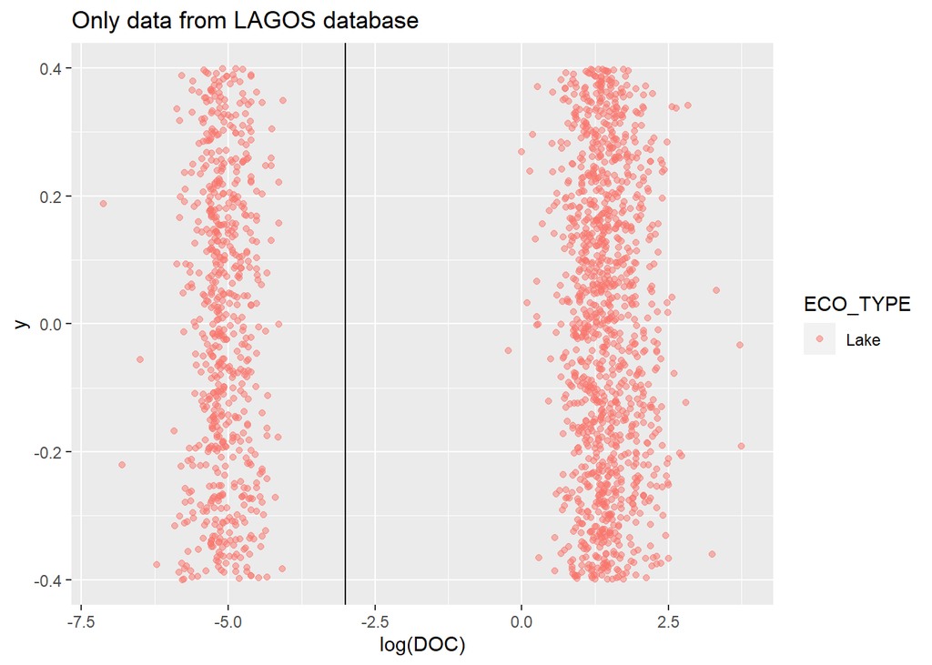

```r
ALL_CNP %>%
  filter(str_detect(SITE_ID, "LAGOS")) %>%
  ggplot() +
  geom_jitter(aes(x = log(DOC), y = 0, col = ECO_TYPE), width = 0, alpha = 0.5) +
  geom_vline(xintercept = -3) +
  labs(title = "Only data from LAGOS database")
```

Hmm, if it was a unit error, shouldn’t all data from the LAGOS database have this issue?

Let’s look at spatial distribution of these lakes

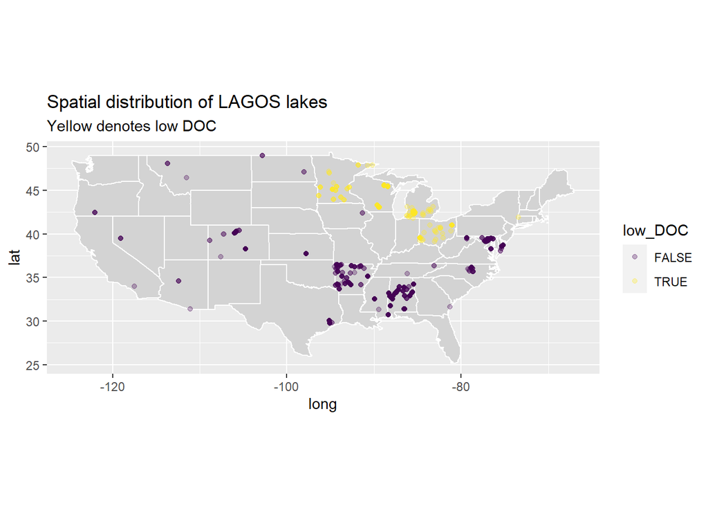

```r
state_map <- map_data("state")

# plot lakes
ggplot() +
  geom_map(data = state_map, map = state_map,
           aes(long, lat, map_id = region),
           color = "white", fill = "lightgray") +
  geom_point(data = ALL_CNP %>% mutate(low_DOC = log(DOC) < -3) %>% filter(str_detect(SITE_ID, "LAGOS")),
             mapping = aes(x = LON, y = LAT, color = low_DOC),
             alpha = 0.3) +
  scale_color_viridis(discrete = TRUE) +
  coord_equal(ratio = 1)  +
  labs(title = "Spatial distribution of LAGOS lakes",
       subtitle = "Yellow denotes low DOC")
```

We can see that only the LAGOS lake locations around the Great Lakes region have really low DOC. All other sites do not have this issue.

```r
# get LAGOS subset of low DOC data
low_DOC_lagos <- low_DOC %>% filter(str_detect(SITE_ID, "LAGOS"))
low_DOC_lagos_n <- low_DOC_lagos %>% group_by(SITE_ID) %>% summarise(n_samples = n())
low_DOC_lagos_n %>% filter(n_samples == 1) %>% nrow()
```

```
## [1] 46
```

```r
low_DOC_lagos_n %>% filter(n_samples > 5) %>% nrow()
```

```
## [1] 17
```

```r
# grab lakes with at least 5 sample dates to plot
low_DOC_lagos_plot <- low_DOC_lagos_n %>% filter(n_samples > 5) %>% pull(SITE_ID)
```

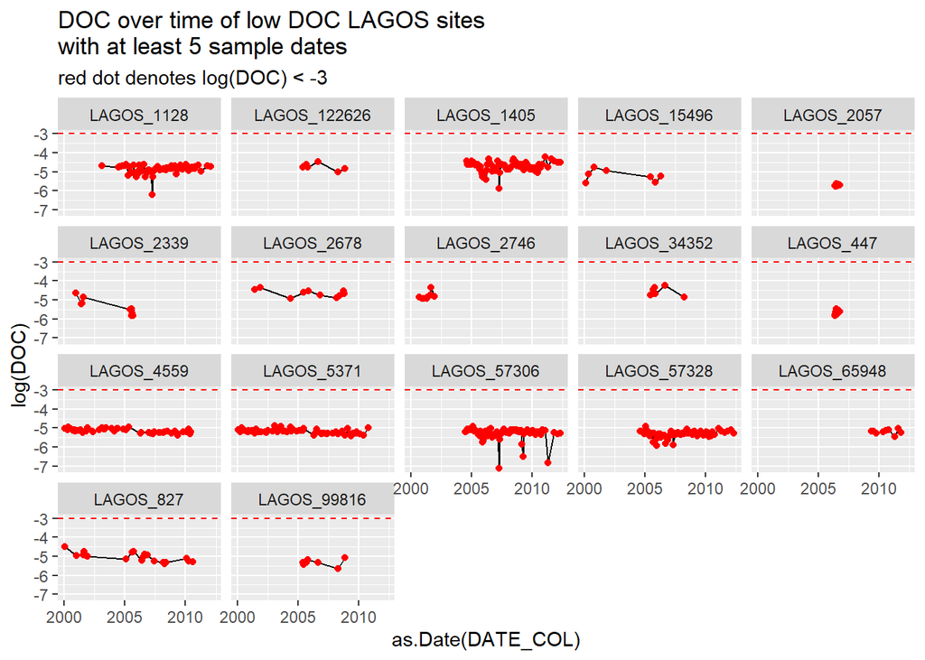

```r
ALL_CNP %>%
  filter(SITE_ID %in% low_DOC_lagos_plot) %>%
  ggplot() +
  geom_line(aes(as.Date(DATE_COL), y = log(DOC))) +
  # points from subset of low DOC sites, but doesn't restrict possible points based on DOC
  geom_point(data = ALL_CNP %>%
               filter(str_detect(SITE_ID, "LAGOS")) %>%
               filter(SITE_ID %in% low_DOC_lagos_plot),
             mapping = aes(as.Date(DATE_COL), y = log(DOC)), col = "red") +
  geom_hline(yintercept = -3, linetype = "dashed", col = "red") +
  facet_wrap(~SITE_ID) +
  labs(title = "DOC over time of low DOC LAGOS sites \nwith at least 5 sample dates",
       subtitle = "red dot denotes log(DOC) < -3")
```

LAGOS lakes with at least 5 sampling dates all consistently have very low DOC (log(DOC) < -3).

# Low DOC rivers

```r
# rivers with low DOC
# all from ECN T08
low_DOC %>% filter(ECO_TYPE == "River/Stream") %>% knitr::kable(caption = "Rivers with low DOC")
```

Rivers with low DOC

| DATE_COL | SITE_ID | LAT | LON | ECO_TYPE | DOC | NO3.as.N | PO4.as.P | UNIT |
| --- | --- | --- | --- | --- | --- | --- | --- | --- |
| 2014-04-02 | ECN_T08_2 | 51.78135 | -1.336058 | River/Stream | 0.010 | 2.34 | 0.010 | mg/L |
| 2014-04-02 | ECN_T08_1 | 51.78135 | -1.336058 | River/Stream | 0.032 | 2.48 | 0.032 | mg/L |
| 2014-04-09 | ECN_T08_1 | 51.78135 | -1.336058 | River/Stream | 0.029 | 1.79 | 0.029 | mg/L |
| 2014-04-09 | ECN_T08_2 | 51.78135 | -1.336058 | River/Stream | 0.011 | 2.35 | 0.011 | mg/L |

On two sampling dates, these two river sites had unusually low DOC readings.

Plot low DOC rivers

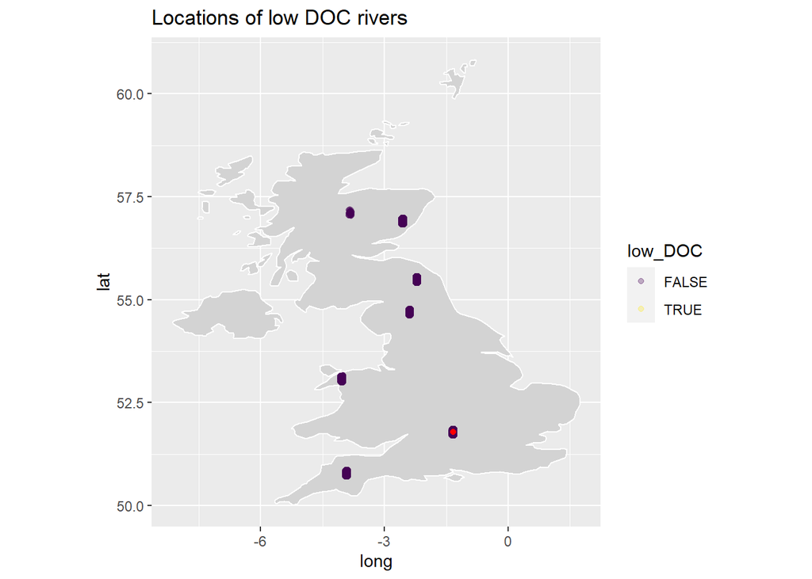

```r
# get UK map borders
uk_map <- map_data("world", region = "uk")
# plot where low doc rivers are
ggplot() +
  geom_map(data = uk_map, map = uk_map,
           aes(long, lat, map_id = region),
           color = "white", fill = "lightgray") +
  geom_jitter(data = ALL_CNP %>% mutate(low_DOC = log(DOC) < -3) %>% filter(str_detect(SITE_ID, "ECN")),
             mapping = aes(x = LON, y = LAT, color = low_DOC),
             alpha = 0.3) +
  geom_point(data = low_DOC %>% filter(str_detect(SITE_ID, "ECN")),
             mapping = aes(x = LON, y = LAT), color = "red") +
  coord_equal(ratio = 1) +
  scale_color_viridis(discrete = TRUE) +
  labs(title = "Locations of low DOC rivers")
```

There are many sampling dates for these rivers. So we can’t actually see the yellow points with low DOC because of over plotting. Instead of placed a red dot on the site that has had unusually low DOC, which is located in southern England.

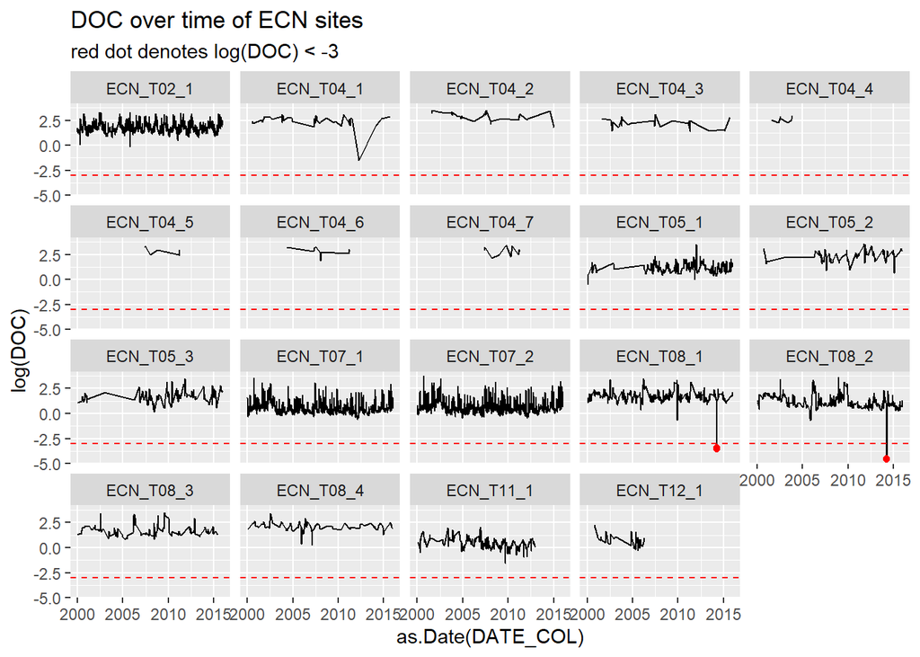

```r
ALL_CNP %>% mutate(low_DOC = log(DOC) < -3) %>% filter(str_detect(SITE_ID, "ECN")) %>%
  ggplot() +
  geom_line(aes(as.Date(DATE_COL), y = log(DOC))) +
  geom_point(data = low_DOC %>% filter(str_detect(SITE_ID, "ECN") ),
             mapping = aes(as.Date(DATE_COL), y = log(DOC)), col = "red") +
  geom_hline(yintercept = -3, linetype = "dashed", col = "red") +
  facet_wrap(~SITE_ID) +
  labs(title = "DOC over time of ECN sites",
       subtitle = "red dot denotes log(DOC) < -3")
```

I don’t know if these are correct data. Maybe an instrumentation error? Very far from typical values.

# TO DO

Go back to original data and figure out what went wrong. I don’t think I’m qualified to do this since I wasn’t involved in the data collection/processing step.